# Projected VMTs for Grenada (2020 & 2040)

Manas Bhatia

2024-11-17

## Introduction

This analysis projects vehicle miles traveled (VMT) for Grenada in the years 2020 and 2040 by simulating population growth, vehicle ownership, and urban travel distances between the two main urban centers (St. George and Grenville). We run 20 stochastic simulations per target year, sampling one of two speculative annual population growth rates (1.003 or 1.005) and using spatial centroids to compute inter-city travel distances. The output table lists VMT values for each simulation, and we report the mean projected VMT.

## Data Preperation

### 01. Load libraries

### 02. Load Data

### 03. Reproject and filter data

### 04. Visualize Data

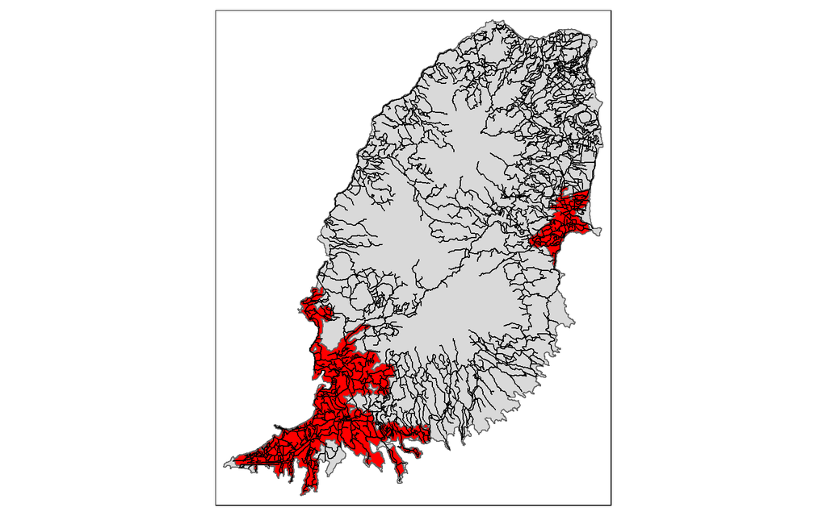

### 05. Create edges’ ID from roads

|  | fid | cat | OBJECTID | FNODE_ | TNODE_ | LPOLY_ | RPOLY_ | LENGTH | RDS0102_ | RDS0102_ID | TYPE | CLASS | CONDITION | DRAINS | CODE | NAME | networkGrp | geometry |
| --- | --- | --- | --- | --- | --- | --- | --- | --- | --- | --- | --- | --- | --- | --- | --- | --- | --- | --- |
| 1 | 1 | 3 | 3 | 3 | 5 | 1 | 3 | 3831.7774 | 3 | 13 | Secondary | Concrete | Poor | Earth | SCPE | Mt. Alexander | 0 |  |
| 2 | 2 | 5 | 5 | 8 | 3 | 1 | 3 | 13982.6772 | 5 | 13 | Secondary | Concrete | Poor | Earth | SCPE | Mt. Alexander | 0 |  |
| 3 | 3 | 6 | 6 | 9 | 8 | 1 | 1 | 5946.4911 | 6 | 13 | Secondary | Asphalt | Very Poor | Earth | SAVPE | Mt. Alexander | 0 |  |
| 4 | 4 | 10 | 10 | 16 | 11 | 3 | 3 | 12734.2290 | 10 | 13 | Tertiary | Concrete | Poor | Earth | TeCPE | Mt. Rodney | 0 |  |
| 5 | 5 | 17 | 20 | 37 | 36 | 1 | 1 | 275.9858 | 20 | 12 | Main Road | Concrete | Good | Concrete | MCGC | Helvellyn | 0 |  |
| 6 | 6 | 18 | 21 | 30 | 37 | 1 | 1 | 17162.6609 | 21 | 12 | Main Road | Asphalt | Good | Earth | MAGE | NA | 0 |  |
| 7 | 7 | 21 | 24 | 38 | 40 | 3 | 3 | 8116.8138 | 24 | 14 | Tertiary | Concrete | Good | Concrete | TeCGC | Mt. Craven | 0 |  |
| 8 | 8 | 30 | 33 | 35 | 54 | 1 | 1 | 34371.2730 | 33 | 12 | Main Road | Asphalt | Good | Concrete | MAGC | Marli | 0 |  |
| 9 | 9 | 31 | 34 | 53 | 56 | 3 | 3 | 9851.3123 | 34 | 14 | Track | Unpaved | Moderate | Earth | TrUME | Welcome Hall | 0 |  |
| 10 | 10 | 37 | 41 | 61 | 60 | 1 | 1 | 387.6577 | 41 | 13 | Secondary | Concrete | Good | Concrete | SCGC | NA | 0 |  |

[output cut: 4198 more lines]

|  | edgeID | geometry |
| --- | --- | --- |
| 1 | 1 |  |
| 2 | 2 |  |
| 3 | 3 |  |
| 4 | 4 |  |
| 5 | 5 |  |
| 6 | 6 |  |
| 7 | 7 |  |
| 8 | 8 |  |
| 9 | 9 |  |
| 10 | 10 |  |

[output cut: 4198 more lines]

### 06. Extract nodes from edges, taking the first the last node from each edge, and labelling them as “start” and “end”

| X | Y | edgeID | start_end |
| --- | --- | --- | --- |
| 645985.8 | 1352629 | 1 | start |
| 646070.7 | 1352590 | 1 | end |
| 645806.8 | 1352377 | 2 | start |
| 645985.8 | 1352629 | 2 | end |
| 645668.4 | 1352359 | 3 | start |
| 645806.8 | 1352377 | 3 | end |
| 646500.1 | 1352125 | 4 | start |
| 646686.4 | 1352337 | 4 | end |
| 648487.1 | 1351353 | 5 | start |
| 648486.7 | 1351360 | 5 | end |

[output cut: 8406 more lines]

### 07. Give each node a unique ID

| X | Y | edgeID | start_end | nodeID |
| --- | --- | --- | --- | --- |
| 645985.8 | 1352629 | 1 | start | 1 |
| 646070.7 | 1352590 | 1 | end | 2 |
| 645806.8 | 1352377 | 2 | start | 3 |
| 645985.8 | 1352629 | 2 | end | 1 |
| 645668.4 | 1352359 | 3 | start | 4 |
| 645806.8 | 1352377 | 3 | end | 3 |
| 646500.1 | 1352125 | 4 | start | 5 |
| 646686.4 | 1352337 | 4 | end | 6 |
| 648487.1 | 1351353 | 5 | start | 7 |
| 648486.7 | 1351360 | 5 | end | 8 |

[output cut: 8406 more lines]

### 08. Store the start and end nodes with their node IDs and their edge ID

### 09. Add to edges - the source node and target node - rename their node IDs to “from” and “to”

| edgeID | from | to | geometry |
| --- | --- | --- | --- |
| 1 | 1 | 2 |  |
| 2 | 3 | 1 |  |
| 3 | 4 | 3 |  |
| 4 | 5 | 6 |  |
| 5 | 7 | 8 |  |
| 6 | 9 | 7 |  |
| 7 | 10 | 11 |  |
| 8 | 12 | 13 |  |
| 9 | 14 | 15 |  |
| 10 | 16 | 17 |  |

[output cut: 4198 more lines]

### 10. Remove duplicate nodes and convert nodes into sf objects using the x and y coordinates

|  | nodeID | geometry |
| --- | --- | --- |
| 1 | 1 |  |
| 2 | 2 |  |
| 3 | 3 |  |
| 4 | 4 |  |
| 5 | 5 |  |
| 6 | 6 |  |
| 7 | 7 |  |
| 8 | 8 |  |
| 9 | 9 |  |
| 10 | 10 |  |

[output cut: 3730 more lines]

### 11. Visualise the Nodes

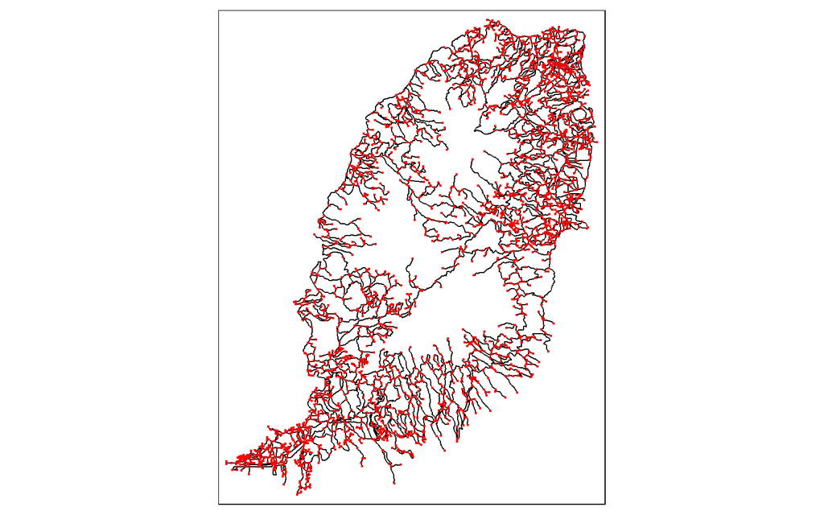

### 12. Convert into tidygraph object

```
## # A tbl_graph: 3740 nodes and 4208 edges
## #
## # An undirected multigraph with 132 components
## #
## # Edge Data: 4,208 × 5 (active)
##     from    to edgeID                                            geometry length
##    <int> <int>  <dbl>                                    <LINESTRING [m]>    [m]
##  1     1     2      1 (645985.8 1352629, 645993.5 1352628, 646004.5 1352…  94.3
##  2     1     3      2 (645806.8 1352377, 645811.1 1352381, 645826.8 1352… 358.
##  3     3     4      3 (645668.4 1352359, 645705.9 1352360, 645732 135236… 152.
##  4     5     6      4 (646500.1 1352125, 646502.2 1352147, 646507.6 1352… 324.
##  5     7     8      5                (648487.1 1351353, 648486.7 1351360)   7.01
##  6     7     9      6 (648267.2 1351655, 648268.7 1351645, 648273.8 1351… 436.
##  7    10    11      7 (646943.3 1351343, 646937.1 1351338, 646925.9 1351… 206.
##  8    12    13      8 (647847.9 1351387, 647837.2 1351379, 647831.2 1351… 873.
##  9    14    15      9 (646425.5 1350602, 646419.6 1350609, 646397.7 1350… 250.
## 10    16    17     10                (648834.9 1350504, 648830.1 1350513)   9.85
## # ℹ 4,198 more rows
## #
## # Node Data: 3,740 × 2
##   nodeID           geometry
##    <int>        <POINT [m]>
## 1      1 (645985.8 1352629)
## 2      2 (646070.7 1352590)
## 3      3 (645806.8 1352377)
## # ℹ 3,737 more rows
```

### 13. Towncentre proxies

|  | cities | geometry |
| --- | --- | --- |
| 1 | St George |  |
| 2 | Grenville |  |
| 3 | church |  |

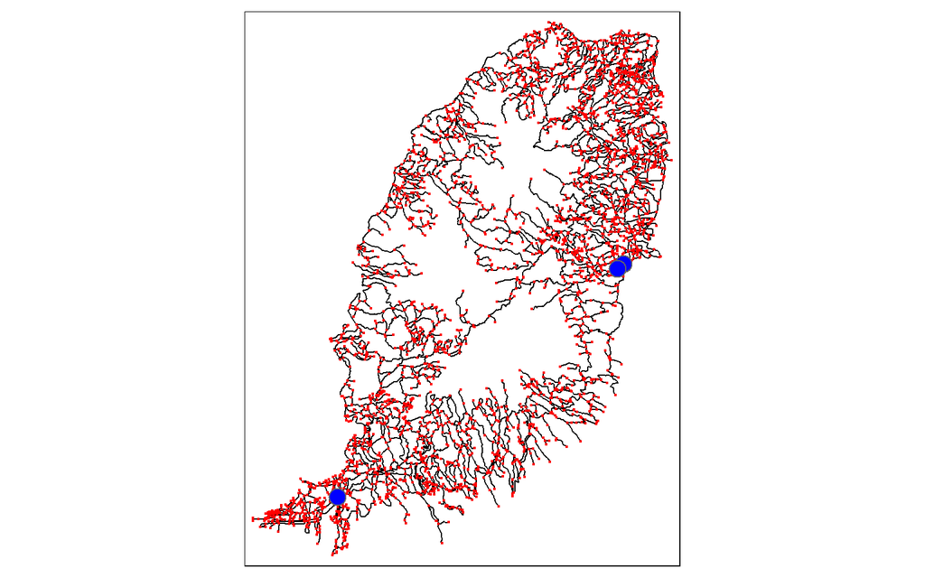

### 14. Set Origins for Trips - which will be centre points of buildings

```
##          [,1]    [,2]
## [1,] 647571.6 1338059
```

### 15. Set Destination for Trips - which will be towncentres

```
##          [,1]    [,2]
## [1,] 635166.9 1328608
```

### 16. Get all coordinates from nodes - we need this since builings/origin is not aligned with the nodes - so we need this to find the closest nodes for the origin

### 17. Find nearest nodes for the origins

| X | Y | edgeID | start_end |
| --- | --- | --- | --- |
| 650312.9 | 1350276 | 1726 | end |

| X | Y | edgeID | start_end |
| --- | --- | --- | --- |
| 635380.6 | 1333711 | 297 | end |

### 18. Shortest distance algorithm

## 19. Extract numeric travel distance

```r
# 1) pull out the raw igraph edge sequence, then coerce to numeric
#    path$epath is a list of edge‐sequences; we want the first (and only) one:
edge_seq <- as.numeric(path$epath[[1]])

# 2) slice your tidygraph’s edges by those row‐numbers, pull the 'length' column and sum it
travel_dist <- graph %>%
  tidygraph::activate(edges) %>%
  dplyr::slice(edge_seq) %>%
  dplyr::pull(length) %>%
  sum() %>%
  as.numeric()

# sanity check
cat("Inter‐city travel distance (meters):", round(travel_dist, 1), "\n")
```

```
## Inter‐city travel distance (meters): 21141.7
```

### 20. Simulation function

```r
library(dplyr)

simulate_vmt <- function(year, n_sims = 20,
                         growth_rates = c(1.003, 1.005),
                         base_pop = 106823,
                         travel_dist) {
  # travel_dist: a numeric, the inter-city distance you computed above
  sims <- seq_len(n_sims)
  map_dfr(sims, function(i) {
    rate <- sample(growth_rates, 1)
    pop  <- base_pop * rate^(year - 2015)
    cars <- ceiling(pop / 2)
    vmt  <- cars * travel_dist
    tibble(
      Year          = year,
      SimNumber     = i,
      PopGrowthRate = rate,
      VMT           = vmt
    )
  })
}
```

### 21. Run simulations & display results

```r
# assume `travel_dist` is already defined:
# travel_dist <- as.numeric(path$…)

vmt_2020 <- simulate_vmt(2020, travel_dist = travel_dist)
vmt_2040 <- simulate_vmt(2040, travel_dist = travel_dist)

all_vmt <- bind_rows(vmt_2020, vmt_2040)

# 1) Print the full table:
knitr::kable(
  all_vmt,
  caption = "Simulated VMT by Year and Simulation Number"
)
```

Simulated VMT by Year and Simulation Number

| Year | SimNumber | PopGrowthRate | VMT |
| --- | --- | --- | --- |
| 2020 | 1 | 1.005 | 1157739550 |
| 2020 | 2 | 1.003 | 1146259617 |
| 2020 | 3 | 1.005 | 1157739550 |
| 2020 | 4 | 1.003 | 1146259617 |
| 2020 | 5 | 1.005 | 1157739550 |
| 2020 | 6 | 1.003 | 1146259617 |
| 2020 | 7 | 1.003 | 1146259617 |
| 2020 | 8 | 1.005 | 1157739550 |
| 2020 | 9 | 1.003 | 1146259617 |
| 2020 | 10 | 1.003 | 1146259617 |
| 2020 | 11 | 1.005 | 1157739550 |
| 2020 | 12 | 1.003 | 1146259617 |
| 2020 | 13 | 1.005 | 1157739550 |
| 2020 | 14 | 1.005 | 1157739550 |
| 2020 | 15 | 1.003 | 1146259617 |
| 2020 | 16 | 1.005 | 1157739550 |
| 2020 | 17 | 1.005 | 1157739550 |
| 2020 | 18 | 1.003 | 1146259617 |
| 2020 | 19 | 1.005 | 1157739550 |
| 2020 | 20 | 1.003 | 1146259617 |
| 2040 | 1 | 1.005 | 1279177361 |
| 2040 | 2 | 1.003 | 1217020821 |
| 2040 | 3 | 1.003 | 1217020821 |
| 2040 | 4 | 1.005 | 1279177361 |
| 2040 | 5 | 1.005 | 1279177361 |
| 2040 | 6 | 1.003 | 1217020821 |
| 2040 | 7 | 1.003 | 1217020821 |
| 2040 | 8 | 1.005 | 1279177361 |
| 2040 | 9 | 1.005 | 1279177361 |
| 2040 | 10 | 1.003 | 1217020821 |
| 2040 | 11 | 1.005 | 1279177361 |
| 2040 | 12 | 1.005 | 1279177361 |
| 2040 | 13 | 1.003 | 1217020821 |
| 2040 | 14 | 1.003 | 1217020821 |
| 2040 | 15 | 1.005 | 1279177361 |
| 2040 | 16 | 1.003 | 1217020821 |
| 2040 | 17 | 1.005 | 1279177361 |
| 2040 | 18 | 1.003 | 1217020821 |
| 2040 | 19 | 1.005 | 1279177361 |
| 2040 | 20 | 1.003 | 1217020821 |

```r
# 2) Compute and print the overall mean:
overall_mean <- mean(all_vmt$VMT)
cat("\n**Mean projected VMT (2020 & 2040):** ",
    round(overall_mean, 1), "\n")
```

**Mean projected VMT (2020 & 2040):** 1200049337

## 21. Interpretation

The 20 stochastic runs for each target year indicate that:

- **2020 mean VMT:** 1.1519996^{9} meters
- **2040 mean VMT:** 1.2480991^{9} meters

That is a projected increase of  
8.3%  
in total vehicle miles traveled over twenty years, under our assumed growth rates and “one car per two people” rule.

**Inference:**  
This upward trend suggests that, without interventions (e.g. improved public transit, demand management, or alternative mobility strategies), Grenada’s total vehicle travel could rise substantially as its population grows. Policymakers should consider measures—such as encouraging shared mobility, investing in non-motorized transport infrastructure, or revisiting vehicle-ownership incentives—to curb this increase in VMT and its associated environmental and congestion impacts.